# Homework 11

Zhenya Ratushko

## Homework Assignment 11

#### Due Friday, December 1, 2023, at 11:59 PM

### Preliminaries

- Directories
  - COURSE/homework/
  - COURSE/homework/hw11/
  - COURSE/data/
  - COURSE/scripts/
- Files
  - COURSE/homework/hw11/hw11.Rmd
  - COURSE/data/boston-marathon-data.csv
  - COURSE/data/dugong.csv
  - COURSE/scripts/viridis.R
  - COURSE/scripts/ggprob.R

### Data

- Some problems use a new data set on lengths and ages of a sample of dugongs in the file `dugong.csv`.
- Additional problems use the Boston Marathon data in the file `boston-marathon-data.csv`. This file is a transformed version of the raw data we used in class and has data for all runners who completed the race in 2010 and 2011. The variable `Time` is the sum of the times from the different portions of the race, each of which begins with “K”.

### Aims

- Practice regression

## Problems

**1.** In a regression problem to estimate $y$ from explanatory variable $x$ from a sample of size $n$, partial summary information is $\bar{x} = 20$ and $\bar{y} = 100$. Regardless of the values of other summary statistics, what is the value the predicted value $\hat{y}$ at a point where $x = 20$? Briefly explain.

> At a point where $x = 20$, the predicted value $\hat{y}$ must be $100$. Least-squares regression lines always pass through ($\bar{x}$, $\bar{y}$), and because of this special property, $\bar{y}$ (which has a value of 100) is equivalent to $\hat{y}$.

**2.** In a regression problem to estimate $y$ from explanatory variable $x$ from a sample of size $n$, partial summary information is $\bar{x} = 20$, $s_x = 5$, $\bar{y} = 100$, and $s_y = 15$. Which of the following values are possible values for the predicted value $\hat{y}$ when the explanatory variable has value $x = 30$? Briefly explain.

**(a)** 50  
**(b)** 70  
**(c)** 100  
**(d)** 120  
**(e)** 150

> 70 and 120 are both possible values for the predicted value $\hat{y}$ when the explanatory variable has value $x = 30$. $x$ is a value that is two standard deviations away from $\bar{x}$ (since $s_x = 5$), which means that the predicted $y$ can be at most two standard deviations away from $\bar{y} = 100$. Since $s_y = 15$, two standard deviations would be 30 in either direction, and since we do not have a correlation coefficient and therefore cannot ascertain if y goes up or down, this leaves us with 70 and 120.

Problems 3–6 are based on the data set in the file *dugong.csv* which relates age (in years) and length (in meters) of a sample of 27 dugongs, a type of marine mammal.

Credit: The *dugong.csv* file is from Data8 at UC-Berkeley.

**3.**

- Read in the *dugong.csv* data set.
- Create a scatter plot with `length` on the x-axis and `age` on the y-axis; be sure to add descriptive axis labels (include units of measurement) and a title.
- Using `geom_smooth()`, add the least-squares line to your plot.

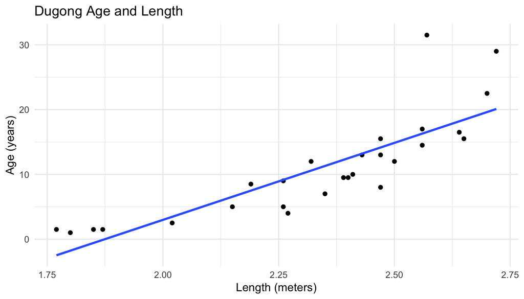

```r
ggplot(dugong, aes(x = length, y = age)) +
  geom_point() +
  xlab("Length (meters)") +
  ylab("Age (years)") +
  ggtitle("Dugong Age and Length") +
  geom_smooth(se = FALSE, method = "lm") +
  theme_minimal()
```

**4.**

- Using the dugong data, calculate the sample means, sample standard deviations, and correlation coefficient of the variables `age` and `length`.
- Using formulas from lecture, calculate the slope and intercept of the least squares regressions line to predict age with length.

```r
dugong_sum = dugong %>%
  summarize(across(everything(), list(mean = mean, sd = sd)),
            r = cor(age, length))

x = dugong$length
y = dugong$age

xbar = mean(x)
ybar = mean(y)
sx = sd(x)
sy = sd(y)
r = cor(x,y)
b1 = r *sy/sx
b0 = ybar - b1*xbar

c(b0, b1)
```

```
## [1] -44.56683  23.77168
```

- Use the dugong data and the functions `lm()` and `coef()` to calculate the slope and intercept of the least squares regression line of age against length (use length to predict age).

```r
dugong_lm = lm(age ~ length, data = dugong)
cf = coef(dugong_lm)
cf
```

```
## (Intercept)      length
##   -44.56683    23.77168
```

```r
summary(dugong_lm)
```

```
##
## Call:
## lm(formula = age ~ length, data = dugong)
##
## Residuals:
##    Min     1Q Median     3Q    Max
## -6.149 -2.805 -0.952  1.515 14.974
##
## Coefficients:
##             Estimate Std. Error t value Pr(>|t|)
## (Intercept)  -44.567      7.521  -5.926 3.48e-06 ***
## length        23.772      3.199   7.430 8.79e-08 ***
## ---
## Signif. codes:  0 '***' 0.001 '**' 0.01 '*' 0.05 '.' 0.1 ' ' 1
##
## Residual standard error: 4.48 on 25 degrees of freedom
## Multiple R-squared:  0.6883, Adjusted R-squared:  0.6758
## F-statistic: 55.21 on 1 and 25 DF,  p-value: 8.794e-08
```

- Verify that you get the same values.

  **5.**
- Add columns with the predicted values and residuals to the dugong data set. *(You can use* **modelr** *functions or just use `mutate()` and calculate these values directly.)*
- Plot the residuals versus length.
  - Add a horizontal line at $y=0$ and appropriate labels on each axis.

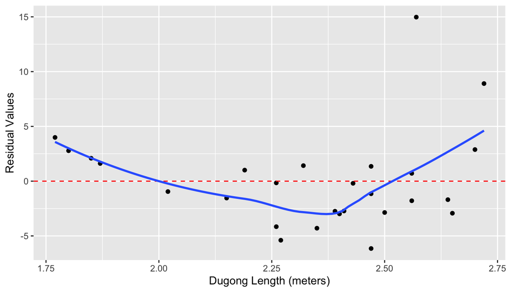

```r
dugong = dugong %>%
  add_residuals(dugong_lm) %>%
  add_predictions(dugong_lm)

ggplot(dugong, aes(x = length, y = resid)) +
  geom_point() +
  xlab("Dugong Length (meters)") +
  ylab("Residual Values") +
  geom_hline(aes(yintercept = 0), color = "red", linetype = "dashed") +
  geom_smooth(se = FALSE)
```

- Describe what the residual plot suggests about the appropriateness of using simple linear regression to predict age from length of dugongs.

**6.**

- Print the summary of the fitted regression model

```r
summary(dugong_lm)
```

```
##
## Call:
## lm(formula = age ~ length, data = dugong)
##
## Residuals:
##    Min     1Q Median     3Q    Max
## -6.149 -2.805 -0.952  1.515 14.974
##
## Coefficients:
##             Estimate Std. Error t value Pr(>|t|)
## (Intercept)  -44.567      7.521  -5.926 3.48e-06 ***
## length        23.772      3.199   7.430 8.79e-08 ***
## ---
## Signif. codes:  0 '***' 0.001 '**' 0.01 '*' 0.05 '.' 0.1 ' ' 1
##
## Residual standard error: 4.48 on 25 degrees of freedom
## Multiple R-squared:  0.6883, Adjusted R-squared:  0.6758
## F-statistic: 55.21 on 1 and 25 DF,  p-value: 8.794e-08
```

- The simple linear regression model for $Y_i$ conditional on the values of $X_i = x_i$ is

$$\mathsf{E}(Y_i \mid X_i = x_i) = \beta_0 + \beta_1 x_i + \varepsilon_i,
\quad \text{for $i = 1, \ldots,n$}$$

where $\varepsilon_i \sim \text{Normal}(0, \sigma)$ for some parameter $\sigma > 0$.

- The parameter $\sigma$ is the unknown population standard deviation of the typical distance between a point $Y_i$ and its true expected value.
- Use the function `sigma()` on the fitted regression object (what you created with `lm()`) to extract the estimate of $\sigma$. Identify where this numerical value appears in the printed summary you made earlier.

```r
sigma(dugong_lm)
```

```
## [1] 4.480469
```

$$\sqrt{ \frac{\sum_{i=1}^n (y_i - \hat{y}_i)^2}{n-2} }$$

where the $i$th residual is $y_i - \hat{y}_i$.

```r
mean(residuals(dugong_lm))
```

```
## [1] -1.438536e-16
```

- Problems 7–8 use the cleaned Boston Marathon data in `boston-marathon-data.csv`.

  **7.**
- Read in the Boston marathon data from the file `boston-marathon-data.csv`.

```r
boston = read_csv("../../data/boston-marathon-data.csv") %>%
  filter(Sex == "female") %>%
  filter(Year == 2010)
```

- Create a scatter plots of `Time` versus `Age` for the female runners in 2010.
  - Add a straight regression line
  - Add a smooth curve
- As there are so many points, you may set `alpha` to a value less than one inside of `geom_point()` to lessen the effects of over-plotting.

[figure not shown]

```r
ggplot(boston, aes(x = Age, y = Time)) +
  geom_point(alpha = 0.05) +
  xlab("Time (minutes)") +
  ylab("Age (years)") +
  ggtitle("Female Boston Marathon Runner Age and Finishing Time") +
  geom_smooth(se = FALSE, method = "lm") +
  geom_smooth(se = FALSE, color = "red") +
  theme_minimal()
```

- Make a residual plot of the residuals versus `Age`.
  - Include a horizontal line at $y=0$
  - Include a smooth curve through the residuals
- In addition, make a density plot of the residuals.

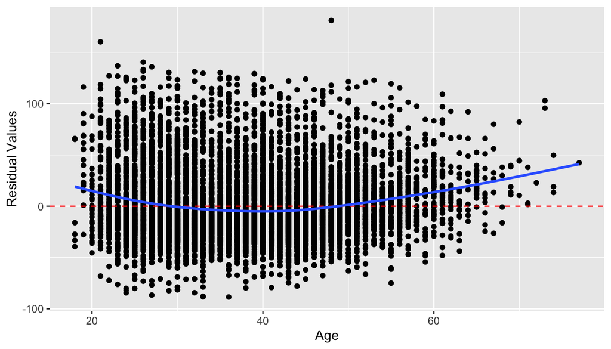

```r
boston_lm = lm(Time ~ Age, data = boston)

boston = boston %>%
  add_residuals(boston_lm) %>%
  add_predictions(boston_lm)

ggplot(boston, aes(x = Age, y = resid)) +
  geom_point() +
  xlab("Age") +
  ylab("Residual Values") +
  geom_hline(aes(yintercept = 0), color = "red", linetype = "dashed") +
  geom_smooth(se = FALSE)
```

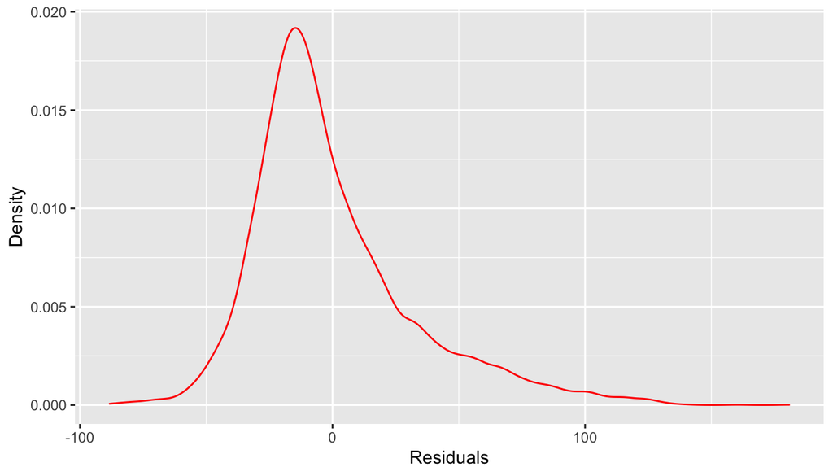

```r
ggplot(boston, aes(x = resid)) +
  geom_density(color = "red", alpha = 0.5) +
  xlab("Residuals") +
  ylab("Density")
```

**8.** Examine the residual plots from the previous problem.

- Is there evidence of strong non-linearity?

> There is evidence of non-linearity, but not particularly strong. The blue smooth curve line is not well-aligned with the red horizontal line in the first residual plot, which shows differences in the residuals for predicted and observed values, but the blue smooth curve line is not so off that it is entirely non-linear (it does appear linear at certain points).
- Is there evidence that the standard deviation of the residuals varies substantially with changes in age?

> No, there is not evidence that the standard deviation of the residuals varies substantially with changes in age, because the residual points are distributed fairly evenly and to similar heights on either side of the distribution’s smooth curve (aside from some greater variation on the rightmost side of the graph).
- Is there evidence that the error distribution for individual residuals is not symmetric?

> Yes, there is evidence that the error distribution for individual residuals is not symmetric, because the right tail has some irregularity and is longer, meaning that the distribution is overall more skewed to the right.